# DP_22134458

```python
# Design Patterns Logbook #
# Connor Martin #
# ID: 22134458 #
# September 2024 #
```

## Logbook Exercise 1

Insert a 'code' cell below. In this do the following:

- line 1 - create a list named "shopping_list" with items: milk, eggs, bread, cheese, tea, coffee, rice, pasta, milk, tea (NOTE: the duplicate items are intentional)
- line 2 - print the list along with a message e.g. "This is my shopping list ..."
- line 3 - create a tuple named "shopping_tuple" with the same items
- line 4 - print the tuple with similar message e.g. "This is my shopping tuple ..."
- line 5 - create a set named "shopping_set" from "shopping_list" by using the set() method
- line 6 - print the set with appropriate message and check duplicate items have been removed
- line 7 - make a dictionary "shopping_dict" - copy and paste the following items and prices: "milk": "£1.20", "eggs": "£0.87", "bread": "£0.64", "cheese": "£1.75", "tea": "£1.06", "coffee": "£2.15", "rice": "£1.60", "pasta": "£1.53".
- line 8 - print the dictionary with an appropriate message

An example of fully described printed output is presented below (some clues here also) Don't worry of your text output is different - it is the contents of the compund variables that matter

```
This is my shopping list ['milk', 'eggs', 'bread', 'cheese', 'tea', 'coffee', 'rice', 'pasta', 'milk', 'tea']
This is my shopping tuple ('milk', 'eggs', 'bread', 'cheese', 'tea', 'coffee', 'rice', 'pasta', 'milk', 'tea')
This is my Shopping_set with duplicates removes {'rice', 'milk', 'pasta', 'cheese', 'eggs', 'tea', 'bread', 'coffee'}
This is my shopping_dict {'milk': '£1.20', 'eggs': '£0.87', 'bread': '£0.64', 'cheese': '£1.75', 'tea': '£1.06', 'coffee': '£2.15', 'rice': '£1.60', 'pasta': '£1.53'}
```

```python
shopping_list = ['milk', 'eggs', 'break', 'cheese', 'tea', 'coffee', 'rice', 'pasta', 'milk', 'tea']
shopping_tuple = ('milk', 'eggs', 'break', 'cheese', 'tea', 'coffee', 'rice', 'pasta', 'milk', 'tea')
shopping_set = set(('milk', 'eggs', 'break', 'cheese', 'tea', 'coffee', 'rice', 'pasta', 'milk', 'tea'))
shopping_dict = { "milk": "£1.20", "eggs": "£0.87", "bread": "£0.64", "cheese": "£1.75", "tea": "£1.06", "coffee": "£2.15", "rice": "£1.60", "pasta": "£1.53"}

print ("this is my shopping list: ", shopping_list)
print ("this is my shopping tuple: ", shopping_tuple)
print ("this is my shopping set: ", shopping_set)
print ("these are the prices: " , shopping_dict)
```

```
this is my shopping list:  ['milk', 'eggs', 'break', 'cheese', 'tea', 'coffee', 'rice', 'pasta', 'milk', 'tea']
this is my shopping tuple:  ('milk', 'eggs', 'break', 'cheese', 'tea', 'coffee', 'rice', 'pasta', 'milk', 'tea')
this is my shopping set:  {'eggs', 'tea', 'pasta', 'rice', 'cheese', 'coffee', 'milk', 'break'}
these are the prices:  {'milk': '£1.20', 'eggs': '£0.87', 'bread': '£0.64', 'cheese': '£1.75', 'tea': '£1.06', 'coffee': '£2.15', 'rice': '£1.60', 'pasta': '£1.53'}
```

## Logbook Exercise 2

Create a 'code' cell below. In this do the following:

- line 1 - Use a comment to title your exercise - e.g. "Unit 2 Exercise"
- line 2 - create a list ... li = ["USA","Mexico","Canada"]
- line 3 - append "Greenland" to the list
- l4 - print the list to de,monstrate that Greenland is attached
- l5 - remove "Greenland"
- l6 - print the list to de,monstrate that Greenland is removed
- l7 - insert "Greenland" at the beginning of the list
- l8 - print the resul of l7
- l9 - shorthand slice the list to extract the first two items - simultaneausly print the output
- l10 - use a negative index to extract the second to last item - simultaneausly print the output
- l11 - use a splitting sequence to extract the middle two items - simultaneausly print the output

An example of fully described printed output is presented below (some clues here also) Don't worry of your text output is different - it is the contents of the list that matter

```
li.append('Greenland') gives ...  ['USA', 'Mexico', 'Canada', 'Greenland']
li.remove('Greenland') gives ...  ['USA', 'Mexico', 'Canada']
li.insert(0,'Greenland') gives ...  ['Greenland', 'USA', 'Mexico', 'Canada']
li[:2] gives ...  ['Greenland', 'USA']
li[-2] gives ...  Mexico
li[1:3] gives ...  ['USA', 'Mexico']
```

```python
# Exercise 2 #
country_list = ["USA","Mexico","Canada"]
print(country_list)
country_list.append("Greenland")
print(country_list)
country_list.remove("Greenland")
print(country_list)
country_list.insert(0,"Greenland")
print(country_list)
print(country_list[:2])
print(country_list[-2])
print(country_list[1:3])
```

```
['USA', 'Mexico', 'Canada']
['USA', 'Mexico', 'Canada', 'Greenland']
['USA', 'Mexico', 'Canada']
['Greenland', 'USA', 'Mexico', 'Canada']
['Greenland', 'USA']
Mexico
['USA', 'Mexico']
```

## Logbook Exercise 3

Create a 'code' cell below. In this do the following:

- on the first line create the following set ... a=[0,1,2,3,4,5,6,7,8,9,10]
- on the second line create the following set ... b=[0,5,10,15,20,25]
- on the third line create the following dictionary ... topscores={"Jo":999, "Sue":987, "Tara":960; "Mike":870}
- use a combination of print() and type() methods to produce the following output

```
list a is ...  [0, 1, 2, 3, 4, 5, 6, 7, 8, 9, 10]
list b is ...  [0, 5, 10, 15, 20, 25]
The type of a is now ... <class 'list'>
```

- on the next 2 lines convert list a and b to sets using set()
- on the following lines use a combination of print(), type() and set notaion (e.g. 'a & b', 'a | b', 'b-a') to obtain the following output

```
set a is ...  {0, 1, 2, 3, 4, 5, 6, 7, 8, 9, 10}
set b is ...  {0, 5, 10, 15, 20, 25}
The type of a is now ... <class 'set'>
Intersect of a and b is [0, 10, 5]
Union of a and b is [0, 1, 2, 3, 4, 5, 6, 7, 8, 9, 10, 15, 20, 25]
Items unique to set b are {25, 20, 15}
```

- on the next 2 lines use print(), '.keys()' and '.values()' methods to obtain the following output

```
topscores dictionary keys are dict_keys(['Jo', 'Sue', 'Tara', 'Mike'])
topscores dictionary values are dict_values([999, 987, 960, 870])
```

```python
a=[0,1,2,3,4,5,6,7,8,9,10]
b=[0,5,10,15,20,25]
topscores= {"Jo": 999, "Sue": 987, "Tara": 960, "Mike": 870}
print("list a is ", a)
print("list b is ", b)
print("The type of a is now ",type(a))
a = set(a)
b = set(b)
print ("set a is ", a)
print ("set b is ", b)
print ("The type of a is now ", type(a))
print ("Intersect of a and b is ", a & b)
print ("Union of a and b is ", a | b)
print ("Items unique to set b are ", b-a)
print ("topscores dictionary keys are ", topscores.keys())
print ("topscores dictionary values are ", topscores.values())
```

```
list a is  [0, 1, 2, 3, 4, 5, 6, 7, 8, 9, 10]
list b is  [0, 5, 10, 15, 20, 25]
The type of a is now  <class 'list'>
set a is  {0, 1, 2, 3, 4, 5, 6, 7, 8, 9, 10}
set b is  {0, 5, 10, 15, 20, 25}
The type of a is now  <class 'set'>
Intersect of a and b is  {0, 10, 5}
Union of a and b is  {0, 1, 2, 3, 4, 5, 6, 7, 8, 9, 10, 15, 20, 25}
Items unique to set b are  {25, 20, 15}
topscores dictionary keys are  dict_keys(['Jo', 'Sue', 'Tara', 'Mike'])
topscores dictionary values are  dict_values([999, 987, 960, 870])
```

### Logbook Exercise 4

Create a 'code' cell below. In this do the following:

- Given the following 4 lists of names, house number and street addresses, towns and postcodes ...

```
["T Cruise","D Francis","C White"]
["2 West St","65 Deadend Cls","15 Magdalen Rd"]
["Canterbury", "Reading", "Oxford"]
["CT8 23RD", "RG4 1FG", "OX4 3AS"]
```

- write a Custom 'address_machine' function that formats 'name', 'hs_number_street', 'town', 'postcode' with commas and spaces between items
- create a 'newlist' that repeatedly calls 'address_machine' and 'zips' items from the 4 lists
- write a 'for loop' that iterates over 'new list' and prints each name and address on a separate line
- the output should appear as follows

```
T Cruise, 2 West St, Canterbury, CT8 23RD
D Francis, 65 Deadend Cls, Reading, RG4 1FG
C White, 15 Magdalen Rd, Oxford, OX4 3AS
```

```python
a = ["T Cruise","D Francis","C White"]
b = ["2 West St","65 Deadend Cls","15 Magdalen Rd"]
c = ["Canterbury", "Reading", "Oxford"]
d = ["CT8 23RD", "RG4 1FG", "OX4 3AS"]

def address_machine(name, hs_number_street, town, postcode):
    info = "{0}, {1}, {2}, {3} ".format(name, hs_number_street, town, postcode)
    return info
newlist = [address_machine(a, b, c, d)
           for a, b, c, d in zip(a, b, c, d)]
for address in newlist:
    print(address)
```

```
T Cruise, 2 West St, Canterbury, CT8 23RD
D Francis, 65 Deadend Cls, Reading, RG4 1FG
C White, 15 Magdalen Rd, Oxford, OX4 3AS
```

## Logbook Exercise 5

Create a 'code' cell below. In this do the following:

- Create a super class "Person" that takes three string and one integer parameters for first and second name, UK Postcode and age in years.
- Give "Person" a method "greeting" that prints a statement along the lines "Hello, my name is Freddy Jones. I am 22 years old and my postcode is HP6 7AJ"
- Create a "Student" class that extends/inherits "Person" and takes additional parameters for degree_subject and student_ID.
- give "Student" a "studentGreeting" method that prints a statement along the lines "My student ID is SN123456 and I am reading Computer Science"
- Use either Python {} format or C-type %s/%d notation to format output strings
- Create 3 student objects and persist these in a list
- Iterate over the three objects and call their "greeting" and "studentGreeting" methods
- Output should be along the lines of the following

```
Hello, my name is Dick Turpin. I am 32 years old and my postcode is HP11 2JZ
My student ID is DT123456 and I am reading Highway Robbery

Hello, my name is Dorothy Turpin. I am 32 years old and my postcode is SO14 7AA
My student ID is DT123457 and I am reading Law

Hello, my name is Oliver Cromwell. I am 32 years old and my postcode is OX35 14RE
My student ID is OC123456 and I am reading History
```

```python
class Person :
    def __init__(self,first_name,second_name,postcode,age):
        self.fn = first_name
        self.sn = second_name
        self.pc = postcode
        self.ag = age
    def setDetails(self,first_name,second_name,postcode,age):
        self.fn = first_name
        self.sn = second_name
        self.pc = postcode
        self.ag = age

    def greeting(self):
         print("Hello, my name is %s %s. I am %d and my postcode is %s" % (self.fn, self.sn, self.ag, self.pc))


class Student(Person) :

    def __init__(self,degree_subject,student_ID):
        self.ds = degree_subject
        self.id = student_ID

    def studentGreeting(self):
        print ("My student ID is %s and I am reading %s" % (self.id,self.ds))

first = Student("Highway Robbery","DT123456")
second = Student("Law","DT123457")
third = Student("History","OC123456")
first.setDetails("Dick","Turpin","HP11 2JZ",32)
second.setDetails("Dorothy","Turpin","SO14 7AA",32)
third.setDetails("Oliver","Cromwell","OX35 14RE",32)

students = [first,second,third]
for student in students:
    student.greeting()

    student.studentGreeting()
```

```
Hello, my name is Dick Turpin. I am 32 and my postcode is HP11 2JZ
My student ID is DT123456 and I am reading Highway Robbery
Hello, my name is Dorothy Turpin. I am 32 and my postcode is SO14 7AA
My student ID is DT123457 and I am reading Law
Hello, my name is Oliver Cromwell. I am 32 and my postcode is OX35 14RE
My student ID is OC123456 and I am reading History
```

## Logbook Exercise 6

```python
#MVC_Template_01
#2014 May 23  by Steven Lipton http://makeAppPie.com
#Controller initializing MVC -- simplest version possible.
#Additional annotations by R Mather - Oct 2018

# MVC EXTENDED WITH DELETE BUTTON

# Tkinter is a Python binding to the Tk GUI toolkit/library - RM
from tkinter import *

# A Model-View-Controller framework for TKinter.
# Model: Data Structure. Controller can send messages to it, and model can respond to message.
# View : User interface elements. Controller can send messages to it. View can call methods from Controller when an event happens.
# Controller: Ties View and Model together. turns UI responses into chages in data.



#Controller: Ties View and Model together.
#       --Performs actions based on View events.
#       --Sends messages to Model and View and gets responses
#       --Has Delegates - RM NOTE: essential for communications between view and model via control

class MyController():
    def __init__(self,parent):
        self.parent = parent
        # CRITICAL PART OF THE MVC
        # RM NOTES:
        # MyController passes a reference to itself (self) when it creates MyModel and MyView objects
        # This allows the MyModel and MyView objects to create 'delegates' (see 'vc' = virtual controller?)
        # The vc objects can then call methods on the MyControl object, thereby allowing the View to update the Model via the Controller
        self.model = MyModel(self)    # initializes the model
        self.view = MyView(self)  #initializes the view
        # Initialize objects in view
        self.view.setEntry_text('Add to Label') # a non cheat way to do MVC with tkinter control variables
        self.view.setLabel_text('Ready')

    #event handlers
    def quitButtonPressed(self):
        self.parent.destroy()
    def addButtonPressed(self):
        self.view.setLabel_text(self.view.entry_text.get())
        # CRITICAL PART OF THE MVC
        # RM NOTES - In one operation:
        #[1] Get the text from the VIEW;
        #[2] Add it to the MODEL by appending it to the list
        self.model.addToList(self.view.entry_text.get())

    def listChangedDelegate(self):
        #model internally changes and needs to signal a change
        print(self.model.getList())

#View : User interface elements.
#       --Controller can send messages to it.
#       --View can call methods from Controller vc when an event happens.
#       --NEVER communicates with Model.
#       --Has setters and getters to communicate with controller

class MyView(Frame):

    def __init__(self,vc):
        self.frame=Frame()
        self.frame.grid(row = 0,column=0)
        self.vc = vc
        self.entry_text = StringVar()
        self.entry_text.set('nil')
        self.label_text = StringVar()
        self.label_text.set('nil')
        self.loadView()

    def loadView(self):
        quitButton = Button(self.frame,text = 'Quit', command= self.vc.quitButtonPressed).grid(row = 0,column = 0)
        addButton = Button(self.frame,text = "Add", command = self.vc.addButtonPressed).grid(row = 0, column = 1)
        entry = Entry(self.frame,textvariable = self.entry_text).grid(row = 1, column = 0, columnspan = 3, sticky = EW)
        label = Label(self.frame,textvariable = self.label_text).grid(row = 2, column = 0, columnspan = 3, sticky = EW)

    def getEntry_text(self):
    #returns a string of the entry text
        return self.entry_text.get()
    def setEntry_text(self,text):
    #sets the entry text given a string
        self.entry_text.set(text)
    def getLabel_text(self):
    #returns a string of the Label text
        return self.label_text.get()
    def setLabel_text(self,text):
    #sets the label text given a string
        self.label_text.set(text)

#Model: Data Structure.
#   --Controller can send messages to it, and model can respond to message.
#   --Uses delegates from vc to send messages to the Control of internal change
#   --NEVER communicates with View
#   --Has setters and getters to communicate with Controller

class MyModel():
    def __init__(self,vc):
        self.vc = vc
        self.myList = ['duck','duck','goose']
        self.count = 0
#Delegates-- Model would call this on internal change
    def listChanged(self):
        self.vc.listChangedDelegate()
#setters and getters
    def getList(self):
        return self.myList
    def initListWithList(self, aList):
        self.myList = aList
    def addToList(self,item):
        print("returned")
        myList = self.myList
        myList.append(item)
        self.myList=myList
        self.listChanged()

def main():
    # Create a root window from the Tk GUI class
    root = Tk()
    frame = Frame(root,bg='#0555ff' )
    root.title('Hello Penguins')
    app = MyController(root)
    root.mainloop()

if __name__ == '__main__':
    main()
```

## Logbook Exercise 7

- Your task is to extend the Observer example below with a pie-chart view of model data and to copy this cell and the solution to your logbook
- The bar chart provides a useful example of structure
- Partial code is provided below for insertion, completion (note '####' requires appropriate replacement) and implementation
- you will also need to create an 'observer' object from the PieView class and attach it to the first 'model'

```
# Pie chart viewer/ConcreteObserver - overrides the update() method
class PieView(####):

    def update(####, ####): #Alert method that is invoked when the notify() method in a concrete subject is invoked
        # Pie chart, where the slices will be ordered and plotted counter-clockwise:
        labels = ####
        sizes = ####
        explode = (0.1, 0, 0, 0, 0, 0)  # only "explode" the 1st slice
        fig1, ax1 = plt.subplots()
        ax1.pie(sizes, explode=explode, labels=labels, autopct='%1.1f%%', shadow=True, startangle=90)
        ax1.axis('equal')  # Equal aspect ratio ensures that pie is drawn as a circle.
        plt.####()
```

```
Generalised Viewer '1: standard text viewer' has:
Name = Model 1;
Labels = ['Python', 'C++', 'Java', 'Perl', 'Scala', 'Lisp'];
Data = [10, 8, 6, 4, 2, 1]
```

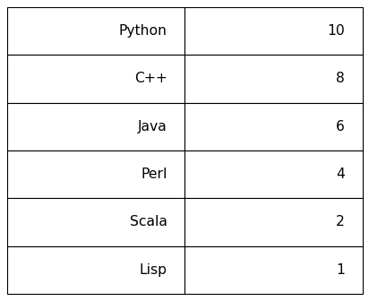

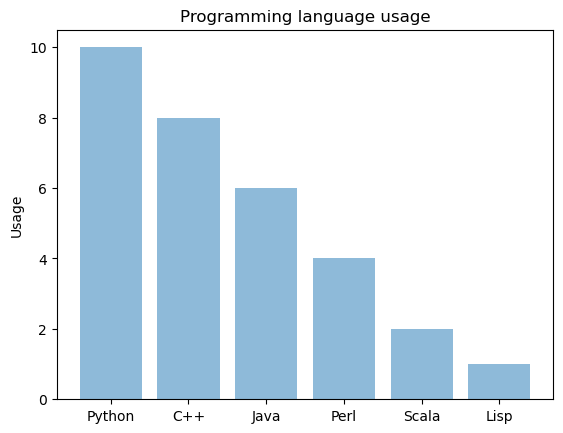

```
Generalised Viewer '1: standard text viewer' has:
Name = Model 1;
Labels = ['C#', 'PHP', 'JavaScript', 'ASP', 'Python', 'Smalltalk'];
Data = [10, 8, 6, 4, 2, 1]
```

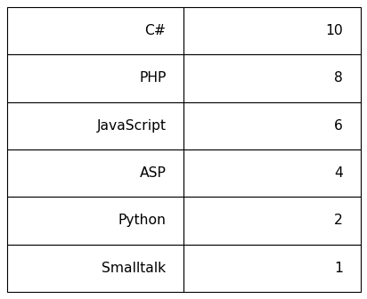

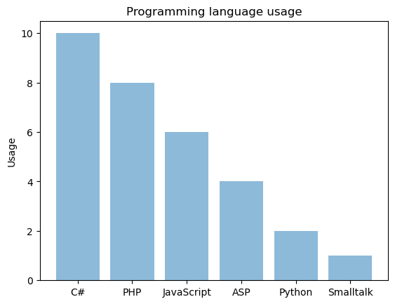

```
Generalised Viewer '1: standard text viewer' has:
Name = Model 1;
Labels = ['C#', 'PHP', 'JavaScript', 'ASP', 'Python', 'Smalltalk'];
Data = [1, 18, 8, 60, 3, 1]
```

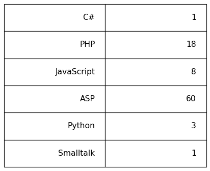

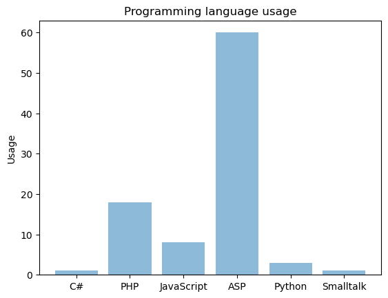

```python
import matplotlib.pyplot as plt
import numpy as np


# Nicely abstracted structure by which any model can notify any observer (view) of changes in the model
class Subject(object): #Represents what is being 'observed'

    def __init__(self):
        self._observers = [] # This where references to all the observers are being kept
                             # Note that this is a one-to-many relationship: there will be one subject to be observed by multiple _observers

    def attach(self, observer):
        if observer not in self._observers: #If the observer is not already in the observers list
            self._observers.append(observer) # append the observer to the list

    def detach(self, observer): #Simply remove the observer
        try:
            self._observers.remove(observer)
        except ValueError:
            pass

    def notify(self, modifier=None):
        for observer in self._observers: # For all the observers in the list
            if modifier != observer: # Don't notify the observer who is actually doing the updating
                observer.update(self) # Alert the observers!

# Represents the 'data' for which changes will produce notifications to any registered view/observer objects
class Model(Subject): # Extends the Subject class

    def __init__(self, name):
        Subject.__init__(self)
        self._name = name # Set the name of the model
        self._labels = ['Python', 'C++', 'Java', 'Perl', 'Scala', 'Lisp']
        self._data = [10,8,6,4,2,1]

    @property #Getter that gets the labels
    def labels(self):
        return self._labels

    @labels.setter #Setter that sets the labels
    def labels(self, labels):
        self._labels = labels
        self.notify() # Notify the observers whenever somebody changes the labels

    @property #Getter that gets the data
    def data(self):
        return self._data

    @data.setter #Setter that sets the labels
    def data(self, data):
        self._data = data
        self.notify() # Notify the observers whenever somebody changes the data


# This is the 'standard' view/observer which also acts as an 'abstract' class whereby deriving Bar/Chart/Table views override the update() method
# This 'abstracted' layer is always shown in examples but is important to demonstrate potential polymorphic behaviour of update()
class View():

    def __init__(self, name=""):
         self._name = name #Set the name of the Viewer

    def update(self, subject): #Alert method that is invoked when the notify() method in a concrete subject is invoked
        print("Generalised Viewer '{}' has: \nName = {}; \nLabels = {}; \nData = {}".format(self._name, subject._name, subject._labels, subject._data))

# Table 'chart' viewer/ConcreteObserver - overrides the update() method
class TableView(View):

    def update(self, subject): #Alert method that is invoked when the notify() method in a concrete subject is invoked
        fig = plt.figure(dpi=80)
        ax = fig.add_subplot(1,1,1)
        table_data = list(map(list,zip(subject._labels, subject._data)))
        table = ax.table(cellText=table_data, loc='center')
        table.set_fontsize(14)
        table.scale(1,4)
        ax.axis('off')
        plt.show()

# Pie chart viewer/ConcreteObserver - overrides the update() method
class PieView(View):

    def update(self, subject): #Alert method that is invoked when the notify() method in a concrete subject is invoked
        # Pie chart, where the slices will be ordered and plotted counter-clockwise:
        labels = ['C#','PHP','JavaScript','ASP','Python','Smalltalk']
        sizes = [1,18,8,60,3,1]
        explode = (0.1, 0, 0, 0, 0, 0)  # only "explode" the 1st slice
        fig1, ax1 = plt.subplots()
        ax1.pie(sizes, explode=explode, labels=labels, autopct='%1.1f%%', shadow=True, startangle=90)
        ax1.axis('equal')  # Equal aspect ratio ensures that pie is drawn as a circle.
        plt.show()

# Bar chart viewer/ConcreteObserver - overrides the update() method
class BarView(View):

    def update(self, subject): #Alert method that is invoked when the notify() method in a concrete subject is invoked
        objects = subject._labels
        y_pos = np.arange(len(objects))
        performance = subject._data
        plt.bar(y_pos, performance, align='center', alpha=0.5)
        plt.xticks(y_pos, objects)
        plt.ylabel('Usage')
        plt.title('Programming language usage')
        plt.show()

#Let's create our subjects
m1 = Model("Model 1")
m2 = Model("Model 2") # This is never used!

#Let's create our observers
v1 = View("1: standard text viewer")
v2 = TableView("2: table viewer")
v3 = BarView("3: bar chart viewer")
v4 = PieView("4: pie chart viewer")
####

#Let's attach our observers to the first model
m1.attach(v1)
m1.attach(v2)
m1.attach(v3)
m1.attach(v4)
####

# Let's just call the notify() method to see all the charts in their unchanged state
m1.notify()

# Now Let's change the properties of our first model
# Change 1 triggers all 4 views and updates their labels
m1.labels = ['C#','PHP','JavaScript','ASP','Python','Smalltalk']
# Change 2 triggers all 4 views and updates their data
m1.data = [1,18,8,60,3,1]
```

[output not shown]

## Logbook Exercise 8

- Your task is to extend the modified version of Burkhard Meier's button factory (below) to create a text field factory
- In tkinter textfields are 'Entry' widgets
- Similary to the button factory structure you will need:
- a concrete ***tk.Entry*** widget factory class - name it TextFactory()
- the TextFactory's Factory Method - name it create_text(...)
- an abstract product - name it TextBase() and give it default attributes 'textvariable' and 'background'
- ... the constructor code for the tk.Entry widgets will be something like

```
       tk_string = tk.StringVar()
       tk_string.set(self.textvariable)
       super().__init__(frame, textvariable=tk_string, background=self.background, foreground="white")
       self.grid(column=1, row=row)
```

#### Challenge question

- At present the example has a 2x 'concrete' creators. As a comment just above the line `import tkinter as tk` briefly explain what you would need to do to refactor code so that the concrete creators extended an abstract class/interface called ***Creator*** (i.e. just as it appears in Gamma et al. (1995) and on slide 2)

```python
'''
Example modified from Meier, B (2017) Python GUI Programming Cookbook, Second Edition.  Packt Publishing

Refactored by Justin Cross November 2023

'''

import tkinter as tk
from tkinter import ttk

class ButtonBase(tk.Button):
    title      = 'Button'
    relief     = 'flat'
    foreground = 'white'

    # The constructor requires the LabelFrame object where the button will be placed together with its row position
    def __init__(self, frame, row):
        # Call the tk.Button constructor passing in the required parameters
        super().__init__(frame, text=self.title, relief=self.relief, foreground=self.foreground)
        self.grid(column=0, row=row)

# Concrete Product buttons
class ButtonRidge(ButtonBase):
    title      = 'Ridge Button'
    relief     = 'ridge'
    foreground = 'red'

class ButtonSunken(ButtonBase):
    title      = 'Sunken Button'
    relief     = 'sunken'
    foreground = 'blue'

class ButtonGroove(ButtonBase):
    title      = 'Groove Button'
    relief     = 'groove'
    foreground = 'green'

class ButtonFactory():
    _button_classes = [ButtonRidge, ButtonSunken, ButtonGroove]

    # The factory method
    def create_button(self, frame, index):
        # Get the class for the type of button we need to create
        button_class = self._button_classes[index]
        # Call the constructor of the class with the required frame and row position
        return button_class(frame, index)

class TextBase(tk.Entry):
    textvariable = 'Default'
    background = 'white'

    def __init__(self, frame, row):
        tk_string = tk.StringVar()
        tk_string.set(self.textvariable)
        super().__init__(frame, textvariable=tk_string, background=self.background, foreground="white")
        self.grid(column=1, row=row)

class TextRed(TextBase):
    textvariable = 'red type'
    background = 'red'

class TextBlue(TextBase):
    textvariable = 'blue type'
    background = 'blue'

class TextGreen(TextBase):
    textvariable = 'green type'
    background = 'green'


class TextFactory():
        _text_classes = [TextRed, TextBlue, TextGreen]

        def create_text(self, frame, index):
            text_class = self._text_classes[index]
            return text_class(frame, index)
class OOP():
    def __init__(self):
        self.window = tk.Tk()
        self.window.title("Python GUI")
        self.create_widgets()

    def create_widgets(self):
        self.frame = ttk.LabelFrame(text=' Widget Factory ')
        self.frame.grid(padx=40, pady=10)

        self.create_buttons()

    def create_buttons(self):
        factory = ButtonFactory()
        factory.create_button(self.frame, 0)
        factory.create_button(self.frame, 1)
        factory.create_button(self.frame, 2)

#==========================
oop = OOP()
oop.window.mainloop()
```